# eda

- PROLOGUE
- IMPORTING LIBRARIES
- DATA DESCRIPTION AND DATA CLEANING
  - 2.1 Import Data
  - 2.2 Data types
  - 2.3 Missing values
  - 2.4 Duplicates
- ANALYSIS
- FINAL CONCLUSIONS
- MODELING

0 PROLOGUE

**FEATURES:**

1. **AGE** - age in years.
2. **SEX** - sex (1 = male; 0 = female).
3. **CP** - chest pain type (1 = typical angina; 2 = atypical angina; 3 = non-anginal pain; 0 = asymptomatic).
4. **TRESTBPS** - resting blood pressure (in mm Hg on admission to the hospital).
5. **CHOL** - serum cholestoral in mg/dl.
6. **FBS** - fasting blood sugar > 120 mg/dl (1 = true; 0 = false).
7. **RESTECG** - resting electrocardiographic results (1 = normal; 2 = having ST-T wave abnormality; 0 = hypertrophy).
8. **THALACH** - maximum heart rate achieved.
9. **EXANG** - exercise induced angina (1 = yes; 0 = no).
10. **OLDPEAK** - ST depression induced by exercise relative to rest.
11. **SLOPE** - the slope of the peak exercise ST segment (2 = upsloping; 1 = flat; 0 = downsloping).
12. **CA** - number of major vessels (0-3) colored by flourosopy.
13. **THAL** - 2 = normal; 1 = fixed defect; 3 = reversable defect.
14. **OUTPUT** - the predicted attribute - diagnosis of heart disease (angiographic disease status) (Value 0 = < diameter narrowing; Value 1 = > 50% diameter narrowing).

1 IMPORTING LIBRARIES

**LIBRARIES:**

1. **PANDAS** - will be required to work with data in tabular representation.
2. **SEABORN, MATPLOTLIB** - required for data visualization.
3. **PANDAS** - required for data visualization.
4. **SKLEARN MODULES** - required for train test split, scaling data, making training pipe line, importing various classification models.
5. **LIGHGBM** - required to import Light Gradient Boosting Machine Classifier.
6. **XGBOOST** - required to import XGBClassifier.

```python
# importing libraries
import pandas as pd
import matplotlib.pyplot as plt
import seaborn as sns
from sklearn.preprocessing import MinMaxScaler, StandardScaler, RobustScaler
from sklearn.pipeline import Pipeline
from sklearn.neighbors import KNeighborsClassifier
from sklearn.model_selection import train_test_split, GridSearchCV
from sklearn.linear_model import LogisticRegression
from sklearn.ensemble import RandomForestClassifier, GradientBoostingClassifier, AdaBoostClassifier, HistGradientBoostingClassifier
from xgboost import XGBClassifier
from lightgbm import LGBMClassifier
from sklearn.svm import SVC
from sklearn.decomposition import PCA
from sklearn.metrics import confusion_matrix
```

2 DATA DESCRIPTION AND DATA CLEANING

2.1 Import Data

```python
# reading data
data = pd.read_csv("heart.csv")
# print out 5 first rows
data.head(5)
```

|  | age | sex | cp | trtbps | chol | fbs | restecg | thalachh | exng | oldpeak | slp | caa | thall | output |
| --- | --- | --- | --- | --- | --- | --- | --- | --- | --- | --- | --- | --- | --- | --- |
| 0 | 63 | 1 | 3 | 145 | 233 | 1 | 0 | 150 | 0 | 2.3 | 0 | 0 | 1 | 1 |
| 1 | 37 | 1 | 2 | 130 | 250 | 0 | 1 | 187 | 0 | 3.5 | 0 | 0 | 2 | 1 |
| 2 | 41 | 0 | 1 | 130 | 204 | 0 | 0 | 172 | 0 | 1.4 | 2 | 0 | 2 | 1 |
| 3 | 56 | 1 | 1 | 120 | 236 | 0 | 1 | 178 | 0 | 0.8 | 2 | 0 | 2 | 1 |
| 4 | 57 | 0 | 0 | 120 | 354 | 0 | 1 | 163 | 1 | 0.6 | 2 | 0 | 2 | 1 |

2.2 Data Types

```python
# printing data types
data.dtypes
```

```
age           int64
sex           int64
cp            int64
trtbps        int64
chol          int64
fbs           int64
restecg       int64
thalachh      int64
exng          int64
oldpeak     float64
slp           int64
caa           int64
thall         int64
output        int64
dtype: object
```

```python
# converting data types
categorical_columns = ['sex', 'cp', 'fbs', 'restecg', 'exng', 'slp', 'caa', 'thall', 'output']
numerical_columns = [col for col in data.columns if col not in categorical_columns]
data[categorical_columns] = data[categorical_columns].astype("category")
data[numerical_columns] = data[numerical_columns].astype("float64")
data.dtypes
```

```
age          float64
sex         category
cp          category
trtbps       float64
chol         float64
fbs         category
restecg     category
thalachh     float64
exng        category
oldpeak      float64
slp         category
caa         category
thall       category
output      category
dtype: object
```

```python
# changing for convenience values in sex column
data["sex"] = data["sex"].map({0: "Female", 1: "Male"})
```

2.3 Missing values

```python
# checking for missing values
print(f"number of missing values\n{data.isnull().sum()}")
data = data.dropna()
```

```
number of missing values
age         0
sex         0
cp          0
trtbps      0
chol        0
fbs         0
restecg     0
thalachh    0
exng        0
oldpeak     0
slp         0
caa         0
thall       0
output      0
dtype: int64
```

**CONCLUSION:** The data has no missing values, so no further transformations are required.

2.4 Duplicates

```python
# Checking for duplicates
print("number of duplicates:",len(data[data.duplicated()]))
# Dropping duplicates
data = data.drop_duplicates()
```

```
number of duplicates: 1
```

**CONCLUSION:** Now the data is clean. We can move on to next part

3. Analysis:

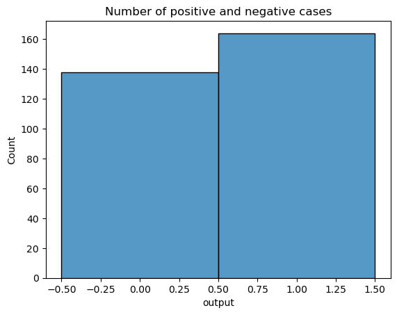

```
Ratios of positive and negative cases output
1    0.543046
0    0.456954
Name: count, dtype: float64
```

```python
sns.histplot(data = data, x = 'output')
plt.title("Number of positive and negative cases")
plt.show()
print(f"Ratios of positive and negative cases {data['output'].value_counts() / len(data)}")
```

**CONCLUSION:** Acceptable distribution of cases in data set.

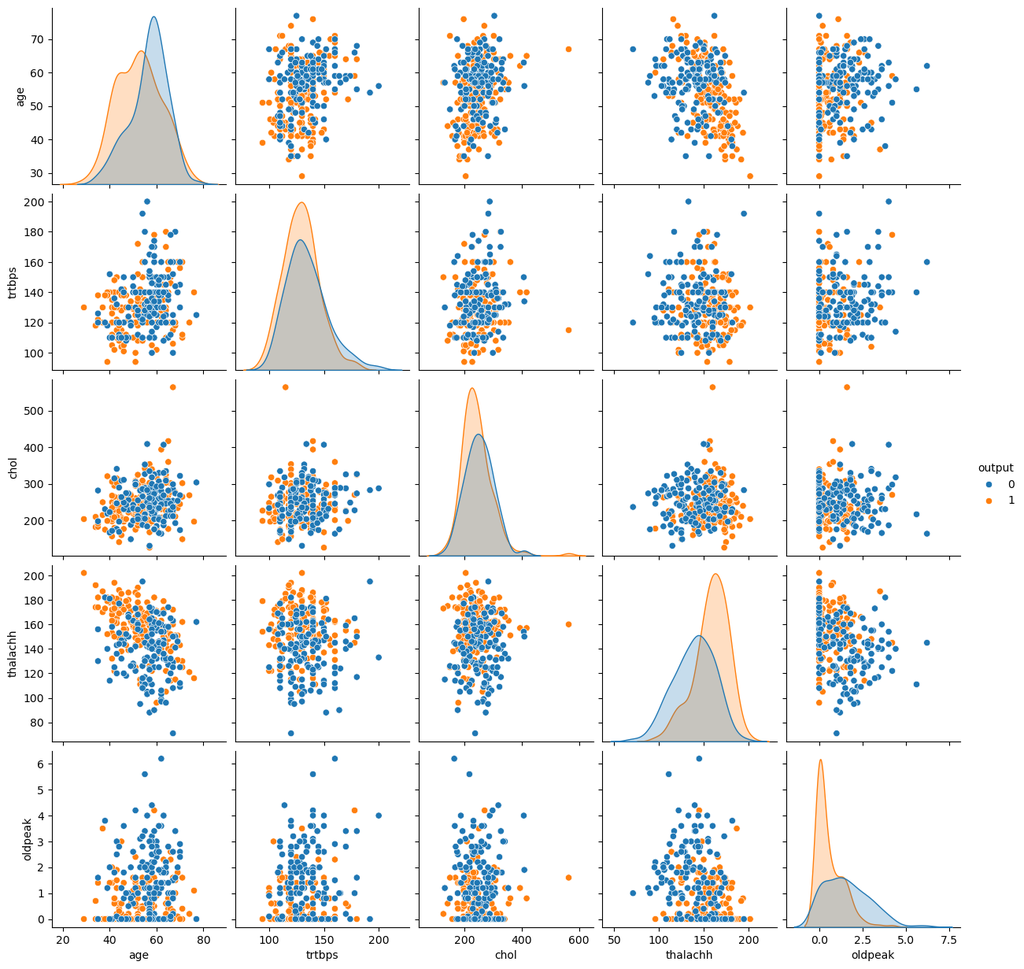

```python
pairplot = sns.pairplot(data, hue = 'output')
plt.show()
```

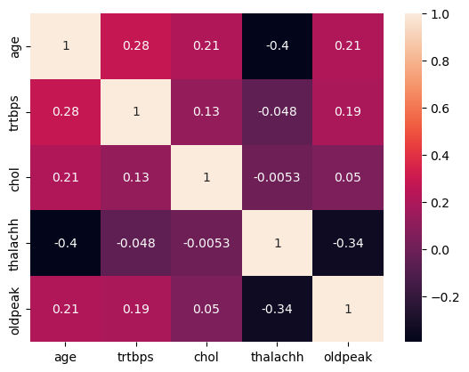

```python
sns.heatmap(data[numerical_columns].corr(), annot = True)
plt.show()
```

**CONCLUSION:**

- **AGE** - Shows a moderate correlation with both resting blood pressure (trtbps) and maximum heart rate (thalachh). Older individuals tend to have higher blood pressure and lower maximum heart rates.
- **TRBPS** - Shows weak correlation with age. Higher resting blood pressure is associated with older age.
- **THALCHH** - Shows a moderate negative correlation with both age and oldpeak. Lower maximum heart rates are associated with older age and higher ST depression values.
- **CHOL** - Generally shows weak correlations with other features, indicating that cholesterol levels are relatively independent of the other variables in this dataset.
- **OLDPEAK** - Shows moderate correlations with age and thalachh, indicating that higher ST depression values are associated with older age and lower maximum heart rates.

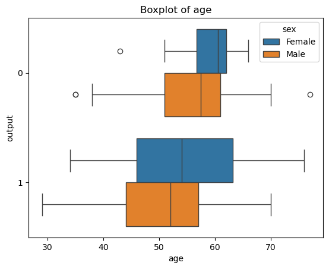

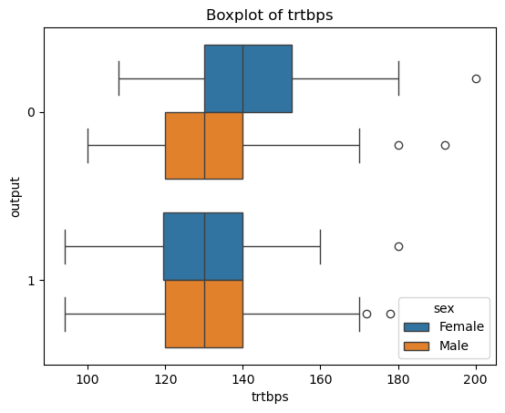

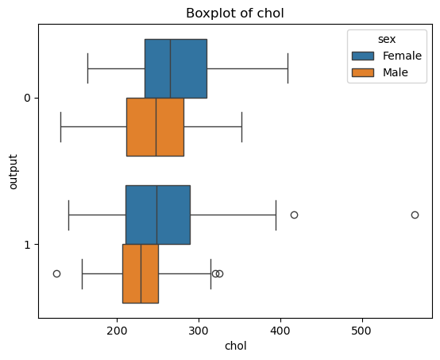

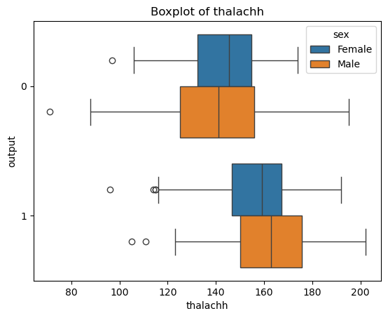

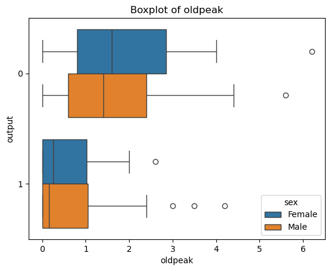

```python
for i in numerical_columns:
    sns.boxplot(x=data[i],y=data["output"], hue = data["sex"])
    plt.title(f'Boxplot of {i}')
    plt.show()
```

**CONCLUSIONS:**

- Differences of features based on output can be seen in features like, **age**, **thalachh**, **oldpeak**.
- Such differences in said features are weakly visible based on gender.
- **trtbps** and **chol** appear not to be very informative in data.

# 4 FINAL CONCLUSIONS

# 5 MODELING

```python
X = data.iloc[:, :-1]
#Creating Dummies for categorical data and splitting data into training set
X = pd.get_dummies(X)
Y = data["output"]
X_train, X_test, Y_train, Y_test = train_test_split(X, Y, test_size = 0.2, random_state = 0)
```

```python
#Creating list of classifiers
scalers = [
    MinMaxScaler(),
    StandardScaler(),
    RobustScaler(),
]
models = [
    KNeighborsClassifier(),
    LogisticRegression(),
    RandomForestClassifier(),
    GradientBoostingClassifier(),
    AdaBoostClassifier(),
    HistGradientBoostingClassifier(),
    XGBClassifier(),
    LGBMClassifier(verbose = -1),
    SVC(verbose=0),
]
```

```python
# Creating parameter grid
param_grid = [
    {
        'classifier': [KNeighborsClassifier()],
        'classifier__n_neighbors': [3, 5, 7, 9],
        'classifier__weights': ['uniform', 'distance'],
        'classifier__metric': ['euclidean', 'manhattan']
    },
    {
        'classifier': [LogisticRegression()],
        'classifier__penalty': ['l1', 'l2', 'elasticnet', 'none'],
        'classifier__C': [0.1, 1, 10, 100],
        'classifier__solver': ['newton-cg', 'lbfgs', 'liblinear', 'sag', 'saga']
    },
    {
        'classifier': [RandomForestClassifier()],
        'classifier__n_estimators': [100, 200, 300],
        'classifier__max_depth': [None, 10, 20, 30],
        'classifier__min_samples_split': [2, 5, 10],
        'classifier__min_samples_leaf': [1, 2, 4]
    },
    {
        'classifier': [GradientBoostingClassifier()],
        'classifier__n_estimators': [100, 200, 300],
        'classifier__learning_rate': [0.01, 0.1, 0.2],
        'classifier__max_depth': [3, 5, 7]
    },
    {
        'classifier': [AdaBoostClassifier()],
        'classifier__n_estimators': [50, 100, 200],
        'classifier__learning_rate': [0.01, 0.1, 1]
    },
    {
        'classifier': [HistGradientBoostingClassifier()],
        'classifier__max_iter': [100, 200, 300],
        'classifier__learning_rate': [0.01, 0.1, 0.2],
        'classifier__max_depth': [None, 10, 20]
    },
    {
        'classifier': [XGBClassifier()],
        'classifier__n_estimators': [100, 200, 300],
        'classifier__learning_rate': [0.01, 0.1, 0.2],
        'classifier__max_depth': [3, 5, 7]
    },
    {
        'classifier': [LGBMClassifier(verbose=-1)],
        'classifier__n_estimators': [100, 200, 300],
        'classifier__learning_rate': [0.01, 0.1, 0.2],
        'classifier__num_leaves': [31, 50, 100]
    },
    {
    'classifier': [SVC()],
    'classifier__C': [1],
    'classifier__gamma': [1],
    'classifier__kernel': ['linear']
    },
]

def get_classifier_position(param_grid, classifier_name):
    for index, param in enumerate(param_grid):
        if param['classifier'][0].__class__.__name__ == classifier_name:
            return index
    return None
```

```python
import warnings

warnings.filterwarnings("ignore")
best_models = []
for i in scalers:
    for j in models:
        n = get_classifier_position(param_grid, j.__class__.__name__)
        pipe = Pipeline(
            [
                ("scaler", i),
                ("pca", PCA(5)),
                ("classifier", j),]
        )
        #cv_scores = cross_val_score(pipe, X_train, Y_train, cv=5, scoring='accuracy')
        grid = GridSearchCV(pipe, param_grid[n], cv=5, scoring='accuracy')
        grid.fit(X_train, Y_train)
        best_model = grid.best_estimator_
        best_models.append(best_model)
        print(f"{i.__class__.__name__} {grid.best_estimator_[2]}:\nAccuracy: {round(best_model.score(X_test, Y_test),2)}")
```

```
MinMaxScaler KNeighborsClassifier(metric='euclidean'):
Accuracy: 0.82
MinMaxScaler LogisticRegression(C=0.1, solver='liblinear'):
Accuracy: 0.84
MinMaxScaler RandomForestClassifier(max_depth=20, min_samples_leaf=2, min_samples_split=10,
                       n_estimators=200):
Accuracy: 0.87
MinMaxScaler GradientBoostingClassifier(learning_rate=0.01, n_estimators=200):
Accuracy: 0.85
MinMaxScaler AdaBoostClassifier(learning_rate=0.1):
Accuracy: 0.9
```

[output not shown]

```
MinMaxScaler HistGradientBoostingClassifier(learning_rate=0.01):
Accuracy: 0.87
MinMaxScaler XGBClassifier(base_score=None, booster=None, callbacks=None,
              colsample_bylevel=None, colsample_bynode=None,
              colsample_bytree=None, device=None, early_stopping_rounds=None,
              enable_categorical=False, eval_metric=None, feature_types=None,
              gamma=None, grow_policy=None, importance_type=None,
              interaction_constraints=None, learning_rate=0.01, max_bin=None,
              max_cat_threshold=None, max_cat_to_onehot=None,
              max_delta_step=None, max_depth=3, max_leaves=None,
              min_child_weight=None, missing=nan, monotone_constraints=None,
              multi_strategy=None, n_estimators=300, n_jobs=None,
              num_parallel_tree=None, random_state=None, ...):
Accuracy: 0.87
MinMaxScaler LGBMClassifier(learning_rate=0.01, verbose=-1):
Accuracy: 0.85
MinMaxScaler SVC(C=1, gamma=1, kernel='linear'):
Accuracy: 0.85
StandardScaler KNeighborsClassifier(metric='euclidean', n_neighbors=9):
Accuracy: 0.89
StandardScaler LogisticRegression(C=0.1, penalty='l1', solver='liblinear'):
Accuracy: 0.87
StandardScaler RandomForestClassifier(max_depth=20, min_samples_leaf=2, min_samples_split=10):
Accuracy: 0.85
StandardScaler GradientBoostingClassifier(learning_rate=0.01, n_estimators=300):
Accuracy: 0.85
StandardScaler AdaBoostClassifier(learning_rate=0.01, n_estimators=200):
Accuracy: 0.84
StandardScaler HistGradientBoostingClassifier(learning_rate=0.01, max_iter=200):
Accuracy: 0.8
StandardScaler XGBClassifier(base_score=None, booster=None, callbacks=None,
              colsample_bylevel=None, colsample_bynode=None,
              colsample_bytree=None, device=None, early_stopping_rounds=None,
              enable_categorical=False, eval_metric=None, feature_types=None,
              gamma=None, grow_policy=None, importance_type=None,
              interaction_constraints=None, learning_rate=0.01, max_bin=None,
              max_cat_threshold=None, max_cat_to_onehot=None,
              max_delta_step=None, max_depth=3, max_leaves=None,
              min_child_weight=None, missing=nan, monotone_constraints=None,
              multi_strategy=None, n_estimators=300, n_jobs=None,
```

[output cut: 19 more lines]

```
              colsample_bylevel=None, colsample_bynode=None,
              colsample_bytree=None, device=None, early_stopping_rounds=None,
              enable_categorical=False, eval_metric=None, feature_types=None,
              gamma=None, grow_policy=None, importance_type=None,
              interaction_constraints=None, learning_rate=0.01, max_bin=None,
              max_cat_threshold=None, max_cat_to_onehot=None,
              max_delta_step=None, max_depth=3, max_leaves=None,
              min_child_weight=None, missing=nan, monotone_constraints=None,
              multi_strategy=None, n_estimators=300, n_jobs=None,
              num_parallel_tree=None, random_state=None, ...):
Accuracy: 0.85
RobustScaler LGBMClassifier(learning_rate=0.01, n_estimators=200, verbose=-1):
Accuracy: 0.89
RobustScaler SVC(C=1, gamma=1, kernel='linear'):
Accuracy: 0.85
```

```python
model_information = {
    "Names": [model.get_params()["steps"][2][1].__class__.__name__ for model in best_models],
    "Scaling_method": [model.get_params()["steps"][0][1].__class__.__name__ for model in best_models],
    "Params": [model.get_params()["steps"][2][1].get_params() for model in best_models],
    "Confusion_Matrix": [confusion_matrix(Y_test, model.predict(X_test)).tolist() for model in best_models],
    "Predictions": [model.predict(X_test).tolist() for model in best_models],
    "Accuracy": [round(model.score(X_test, Y_test),2) for model in best_models]
}

data_information = {
    "training_set": X_train.values.tolist(),
    "test_set": X_test.values.tolist(),
    "train_actual": Y_train.values.tolist(),
    "test_actual": Y_test.values.tolist()
}
```

```python
import json
with open('model_information.json', 'w') as f:
    json.dump(model_information, f)

with open('data_information.json', 'w') as g:
    json.dump(data_information, g)
```

```python
pip freeze > requirementss.txt
```

```python
import re
import os

def clean_requirements(input_file, output_file):
    packages_to_remove = {'pywin32==306', 'pywinpty==2.0.13'}

    with open(input_file, 'r') as infile, open(output_file, 'w') as outfile:
        for line in infile:
            # Remove everything after @
            cleaned_line = re.sub(r'@.*$', '', line).strip()
            # Skip lines that match the packages to remove
            if cleaned_line and cleaned_line not in packages_to_remove:
                outfile.write(cleaned_line + '\n')

clean_requirements('requirementss.txt', 'requirements.txt')
os.remove('requirementss.txt')
```